None

# Table of Contents

## 一、项目介绍

该项目的数据集为2016年天猫双十一美妆销售数据，主要包括产品及其销量和价格，还有评论数量。由于是真实的商业数据，所以做了匿名处理。数据集中将店名更改为产品的品牌名，以保护店家隐私。数据共有27598行和7个特征变量，每一行对应一个产品的销售情况。具体特征如下： |字段名称|字段注释| |:---|:---| |update_time|统计时间| |id|产品编号| |title|产品名称| |price|交易价格| |sale_count|销量| |comment_count|评论数量| |店名|店铺名称|

## 二、读取数据

```python
import pandas as pd
import numpy as np

data = pd.read_csv('/Users/xiajie/Downloads/analysis_data/双十一淘宝美妆数据.csv')
data.head()
```

|  | update_time | id | title | price | sale_count | comment_count | 店名 |
| --- | --- | --- | --- | --- | --- | --- | --- |
| 0 | 2016/11/14 | A18164178225 | CHANDO/自然堂 雪域精粹纯粹滋润霜50g 补水保湿 滋润水润面霜 | 139.0 | 26719.0 | 2704.0 | 自然堂 |
| 1 | 2016/11/14 | A18177105952 | CHANDO/自然堂凝时鲜颜肌活乳液120ML 淡化细纹补水滋润专柜正品 | 194.0 | 8122.0 | 1492.0 | 自然堂 |
| 2 | 2016/11/14 | A18177226992 | CHANDO/自然堂活泉保湿修护精华水（滋润型135ml 补水控油爽肤水 | 99.0 | 12668.0 | 589.0 | 自然堂 |
| 3 | 2016/11/14 | A18178033846 | CHANDO/自然堂 男士劲爽控油洁面膏 100g 深层清洁 男士洗面奶 | 38.0 | 25805.0 | 4287.0 | 自然堂 |
| 4 | 2016/11/14 | A18178045259 | CHANDO/自然堂雪域精粹纯粹滋润霜（清爽型）50g补水保湿滋润霜 | 139.0 | 5196.0 | 618.0 | 自然堂 |

```python
#查看各字段信息
data.info()
```

```
<class 'pandas.core.frame.DataFrame'>
RangeIndex: 27598 entries, 0 to 27597
Data columns (total 7 columns):
 #   Column         Non-Null Count  Dtype
---  ------         --------------  -----
 0   update_time    27598 non-null  object
 1   id             27598 non-null  object
 2   title          27598 non-null  object
 3   price          27598 non-null  float64
 4   sale_count     25244 non-null  float64
 5   comment_count  25244 non-null  float64
 6   店名             27598 non-null  object
dtypes: float64(3), object(4)
memory usage: 1.5+ MB
```

## 三、数据清洗

### 3.1 重复数据处理

```python
#检查是否有重复值
print(data.shape)
print(data.duplicated().sum())
```

```
(27598, 7)
86
```

```python
#删除重复值
data.drop_duplicates(inplace=True)
data.reset_index(drop=True) #重置索引值，并删除旧的索引值
print(data.shape)
```

```
(27512, 7)
```

### 3.2 缺失值处理

```python
# 查看缺失值
data.isnull().any()
```

```
update_time      False
id               False
title            False
price            False
sale_count        True
comment_count     True
店名               False
dtype: bool
```

有两列数据存在缺失值：sale_count和comment_count

```python
# 查看数据结构
data.describe()
```

|  | price | sale_count | comment_count |
| --- | --- | --- | --- |
| count | 27512.000000 | 2.516200e+04 | 25162.000000 |
| mean | 363.423512 | 1.231605e+04 | 1121.741197 |
| std | 614.876153 | 5.241236e+04 | 5277.781581 |
| min | 1.000000 | 0.000000e+00 | 0.000000 |
| 25% | 99.000000 | 2.780000e+02 | 21.000000 |
| 50% | 205.000000 | 1.443000e+03 | 153.000000 |
| 75% | 390.000000 | 6.353000e+03 | 669.000000 |
| max | 11100.000000 | 1.923160e+06 | 202930.000000 |

```python
# 查看sale_count列的众数
mode_01 = data.sale_count.mode()
print(mode_01)

# 查看comment_count列的众数
mode_02 = data.comment_count.mode()
print(mode_02)
```

```
0    0.0
Name: sale_count, dtype: float64
0    0.0
Name: comment_count, dtype: float64
```

此处两列的众数均为0，且由标签数据含义可知销售量和评论数有可能存在为0的情况，因此用0来填充缺失值。

```python
# 填充缺失值
data.fillna(0, inplace=True)
#查看填充后情况
data.isnull().sum()
```

```
update_time      0
id               0
title            0
price            0
sale_count       0
comment_count    0
店名               0
dtype: int64
```

### 3.3 提取表格中有用信息并新增为列

```python
import jieba
title_cut = []
for i in data.title:
    j = jieba.lcut(i)
    title_cut.append(j)

# 对产品名称进行分词，新增title_name_cut列
data['title_name_cut'] = title_cut
data[['title', 'title_name_cut']].head()
```

|  | title | title_name_cut |
| --- | --- | --- |
| 0 | CHANDO/自然堂 雪域精粹纯粹滋润霜50g 补水保湿 滋润水润面霜 | [CHANDO, /, 自然, 堂, , 雪域, 精粹, 纯粹, 滋润霜, 50g, ,... |
| 1 | CHANDO/自然堂凝时鲜颜肌活乳液120ML 淡化细纹补水滋润专柜正品 | [CHANDO, /, 自然, 堂, 凝, 时鲜, 颜肌活, 乳液, 120ML, , 淡... |
| 2 | CHANDO/自然堂活泉保湿修护精华水（滋润型135ml 补水控油爽肤水 | [CHANDO, /, 自然, 堂, 活泉, 保湿, 修护, 精华, 水, （, 滋润, 型... |
| 3 | CHANDO/自然堂 男士劲爽控油洁面膏 100g 深层清洁 男士洗面奶 | [CHANDO, /, 自然, 堂, , 男士, 劲爽, 控油, 洁面膏, , 100g... |
| 4 | CHANDO/自然堂雪域精粹纯粹滋润霜（清爽型）50g补水保湿滋润霜 | [CHANDO, /, 自然, 堂, 雪域, 精粹, 纯粹, 滋润霜, （, 清爽型, ）,... |

```python
# 给商品添加分类
basic_config_data = """护肤品    套装    套装
护肤品    乳液类    乳液    美白乳    润肤乳    凝乳    柔肤液    亮肤乳    菁华乳    修护乳
护肤品    眼部护理    眼霜    眼部精华    眼膜
护肤品    面膜类    面膜
护肤品    清洁类    洗面    洁面    清洁    卸妆    洁颜    洗颜    去角质    磨砂
护肤品    化妆水    化妆水    爽肤水    柔肤水    补水露    凝露    柔肤液    精粹水    亮肤水    润肤水    保湿水    菁华水    保湿喷雾    舒缓喷雾
护肤品    面霜类    面霜    日霜    晚霜    柔肤霜    滋润霜    保湿霜    凝霜    日间霜    晚间霜    乳霜    修护霜    亮肤霜    底霜    菁华霜
护肤品    精华类    精华液    精华水    精华露    精华素
护肤品    防晒类    防晒霜    防晒喷雾
化妆品    口红类    唇釉    口红    唇彩
化妆品    底妆类    散粉    蜜粉    粉底液    定妆粉    气垫    粉饼    BB    CC    遮瑕    粉霜    粉底膏    粉底霜
化妆品    眼部彩妆    眉粉    染眉膏    眼线    眼影    睫毛膏
化妆品    修容类    鼻影    修容粉    高光    腮红
其他    其他    其他"""

# 将字符串basic_config_data转化为字典category_config_map
category_config_map = {}
for line in basic_config_data.split('\n'):
    basic_category_list = line.strip().strip('\n').split('    ')
    main_category = basic_category_list[0]
    sub_category = basic_category_list[1]
    unit_category_list = basic_category_list[2:-1]
    for unit_category in unit_category_list:
        if unit_category and unit_category.strip().strip('    '):
            category_config_map[unit_category] = (main_category, sub_category)

category_config_map
```

```
{'乳液': ('护肤品', '乳液类'),
 '美白乳': ('护肤品', '乳液类'),
 '润肤乳': ('护肤品', '乳液类'),
 '凝乳': ('护肤品', '乳液类'),
 '柔肤液': ('护肤品', '化妆水'),
 '亮肤乳': ('护肤品', '乳液类'),
 '菁华乳': ('护肤品', '乳液类'),
 '眼霜': ('护肤品', '眼部护理'),
 '眼部精华': ('护肤品', '眼部护理'),
 '洗面': ('护肤品', '清洁类'),
 '洁面': ('护肤品', '清洁类'),
 '清洁': ('护肤品', '清洁类'),
 '卸妆': ('护肤品', '清洁类'),
 '洁颜': ('护肤品', '清洁类'),
 '洗颜': ('护肤品', '清洁类'),
 '去角质': ('护肤品', '清洁类'),
 '化妆水': ('护肤品', '化妆水'),
 '爽肤水': ('护肤品', '化妆水'),
 '柔肤水': ('护肤品', '化妆水'),
 '补水露': ('护肤品', '化妆水'),
 '凝露': ('护肤品', '化妆水'),
 '精粹水': ('护肤品', '化妆水'),
 '亮肤水': ('护肤品', '化妆水'),
 '润肤水': ('护肤品', '化妆水'),
 '保湿水': ('护肤品', '化妆水'),
 '菁华水': ('护肤品', '化妆水'),
 '保湿喷雾': ('护肤品', '化妆水'),
 '面霜': ('护肤品', '面霜类'),
 '日霜': ('护肤品', '面霜类'),
 '晚霜': ('护肤品', '面霜类'),
 '柔肤霜': ('护肤品', '面霜类'),
 '滋润霜': ('护肤品', '面霜类'),
 '保湿霜': ('护肤品', '面霜类'),
 '凝霜': ('护肤品', '面霜类'),
 '日间霜': ('护肤品', '面霜类'),
 '晚间霜': ('护肤品', '面霜类'),
 '乳霜': ('护肤品', '面霜类'),
 '修护霜': ('护肤品', '面霜类'),
 '亮肤霜': ('护肤品', '面霜类'),
 '底霜': ('护肤品', '面霜类'),
```

[output cut: 9 more lines]

```
 '定妆粉': ('化妆品', '底妆类'),
 '气垫': ('化妆品', '底妆类'),
 '粉饼': ('化妆品', '底妆类'),
 'BB': ('化妆品', '底妆类'),
 'CC': ('化妆品', '底妆类'),
 '遮瑕': ('化妆品', '底妆类'),
 '粉霜': ('化妆品', '底妆类'),
 '粉底膏': ('化妆品', '底妆类'),
 '眉粉': ('化妆品', '眼部彩妆'),
 '染眉膏': ('化妆品', '眼部彩妆'),
 '眼线': ('化妆品', '眼部彩妆'),
 '眼影': ('化妆品', '眼部彩妆'),
 '鼻影': ('化妆品', '修容类'),
 '修容粉': ('化妆品', '修容类'),
 '高光': ('化妆品', '修容类')}
```

```python
def func1(row):
    sub_type = '' #子类别
    main_type = '' #主类别
    exist = False
    #遍历title_name_cut里每个词语
    for temp in row:
        if temp in category_config_map:
            sub_type = category_config_map.get(temp)[1]
            main_type = category_config_map.get(temp)[0]
            exist = True
            break
    if not exist:
        sub_type = '其他'
        main_type = '其他'

    return [sub_type, main_type]

# 将子类别sub_type新增为一列
data['sub_type'] = data['title_name_cut'].map(lambda r: func1(r)[0])
# 将主类别main_type新增为一列
data['main_type'] = data['title_name_cut'].map(lambda r: func1(r)[1])
data.head()
```

|  | update_time | id | title | price | sale_count | comment_count | 店名 | title_name_cut | sub_type | main_type |
| --- | --- | --- | --- | --- | --- | --- | --- | --- | --- | --- |
| 0 | 2016/11/14 | A18164178225 | CHANDO/自然堂 雪域精粹纯粹滋润霜50g 补水保湿 滋润水润面霜 | 139.0 | 26719.0 | 2704.0 | 自然堂 | [CHANDO, /, 自然, 堂, , 雪域, 精粹, 纯粹, 滋润霜, 50g, ,... | 面霜类 | 护肤品 |
| 1 | 2016/11/14 | A18177105952 | CHANDO/自然堂凝时鲜颜肌活乳液120ML 淡化细纹补水滋润专柜正品 | 194.0 | 8122.0 | 1492.0 | 自然堂 | [CHANDO, /, 自然, 堂, 凝, 时鲜, 颜肌活, 乳液, 120ML, , 淡... | 乳液类 | 护肤品 |
| 2 | 2016/11/14 | A18177226992 | CHANDO/自然堂活泉保湿修护精华水（滋润型135ml 补水控油爽肤水 | 99.0 | 12668.0 | 589.0 | 自然堂 | [CHANDO, /, 自然, 堂, 活泉, 保湿, 修护, 精华, 水, （, 滋润, 型... | 化妆水 | 护肤品 |
| 3 | 2016/11/14 | A18178033846 | CHANDO/自然堂 男士劲爽控油洁面膏 100g 深层清洁 男士洗面奶 | 38.0 | 25805.0 | 4287.0 | 自然堂 | [CHANDO, /, 自然, 堂, , 男士, 劲爽, 控油, 洁面膏, , 100g... | 清洁类 | 护肤品 |
| 4 | 2016/11/14 | A18178045259 | CHANDO/自然堂雪域精粹纯粹滋润霜（清爽型）50g补水保湿滋润霜 | 139.0 | 5196.0 | 618.0 | 自然堂 | [CHANDO, /, 自然, 堂, 雪域, 精粹, 纯粹, 滋润霜, （, 清爽型, ）,... | 面霜类 | 护肤品 |

```python
# 将“是否男士专用”新增为一列
gender = []
for i in range(len(data)):
    if '男' in data.title_name_cut.iloc[i]:
        gender.append('是')
    elif '男士' in data.title_name_cut.iloc[i]:
        gender.append('是')
    elif '男生' in data.title_name_cut.iloc[i]:
        gender.append('是')
    else:
        gender.append('否')

data['是否男士专用'] = gender
data.head()
```

|  | update_time | id | title | price | sale_count | comment_count | 店名 | title_name_cut | sub_type | main_type | 是否男士专用 |
| --- | --- | --- | --- | --- | --- | --- | --- | --- | --- | --- | --- |
| 0 | 2016/11/14 | A18164178225 | CHANDO/自然堂 雪域精粹纯粹滋润霜50g 补水保湿 滋润水润面霜 | 139.0 | 26719.0 | 2704.0 | 自然堂 | [CHANDO, /, 自然, 堂, , 雪域, 精粹, 纯粹, 滋润霜, 50g, ,... | 面霜类 | 护肤品 | 否 |
| 1 | 2016/11/14 | A18177105952 | CHANDO/自然堂凝时鲜颜肌活乳液120ML 淡化细纹补水滋润专柜正品 | 194.0 | 8122.0 | 1492.0 | 自然堂 | [CHANDO, /, 自然, 堂, 凝, 时鲜, 颜肌活, 乳液, 120ML, , 淡... | 乳液类 | 护肤品 | 否 |
| 2 | 2016/11/14 | A18177226992 | CHANDO/自然堂活泉保湿修护精华水（滋润型135ml 补水控油爽肤水 | 99.0 | 12668.0 | 589.0 | 自然堂 | [CHANDO, /, 自然, 堂, 活泉, 保湿, 修护, 精华, 水, （, 滋润, 型... | 化妆水 | 护肤品 | 否 |
| 3 | 2016/11/14 | A18178033846 | CHANDO/自然堂 男士劲爽控油洁面膏 100g 深层清洁 男士洗面奶 | 38.0 | 25805.0 | 4287.0 | 自然堂 | [CHANDO, /, 自然, 堂, , 男士, 劲爽, 控油, 洁面膏, , 100g... | 清洁类 | 护肤品 | 是 |
| 4 | 2016/11/14 | A18178045259 | CHANDO/自然堂雪域精粹纯粹滋润霜（清爽型）50g补水保湿滋润霜 | 139.0 | 5196.0 | 618.0 | 自然堂 | [CHANDO, /, 自然, 堂, 雪域, 精粹, 纯粹, 滋润霜, （, 清爽型, ）,... | 面霜类 | 护肤品 | 否 |

```python
# 新增“销售额”列
data['sale_amount'] = data.sale_count * data.price

# 新增“购买日期”列
data['update_time'] = pd.to_datetime(data['update_time'])

data = data.set_index('update_time')

data['day'] = data.index.day

#删除"title_name_cut"列
del data['title_name_cut']

# 查看最终数据表格
data.head()
```

| update_time | id | title | price | sale_count | comment_count | 店名 | sub_type | main_type | 是否男士专用 | sale_amount | day |
| --- | --- | --- | --- | --- | --- | --- | --- | --- | --- | --- | --- |
| 2016-11-14 | A18164178225 | CHANDO/自然堂 雪域精粹纯粹滋润霜50g 补水保湿 滋润水润面霜 | 139.0 | 26719.0 | 2704.0 | 自然堂 | 面霜类 | 护肤品 | 否 | 3713941.0 | 14 |
| 2016-11-14 | A18177105952 | CHANDO/自然堂凝时鲜颜肌活乳液120ML 淡化细纹补水滋润专柜正品 | 194.0 | 8122.0 | 1492.0 | 自然堂 | 乳液类 | 护肤品 | 否 | 1575668.0 | 14 |
| 2016-11-14 | A18177226992 | CHANDO/自然堂活泉保湿修护精华水（滋润型135ml 补水控油爽肤水 | 99.0 | 12668.0 | 589.0 | 自然堂 | 化妆水 | 护肤品 | 否 | 1254132.0 | 14 |
| 2016-11-14 | A18178033846 | CHANDO/自然堂 男士劲爽控油洁面膏 100g 深层清洁 男士洗面奶 | 38.0 | 25805.0 | 4287.0 | 自然堂 | 清洁类 | 护肤品 | 是 | 980590.0 | 14 |
| 2016-11-14 | A18178045259 | CHANDO/自然堂雪域精粹纯粹滋润霜（清爽型）50g补水保湿滋润霜 | 139.0 | 5196.0 | 618.0 | 自然堂 | 面霜类 | 护肤品 | 否 | 722244.0 | 14 |

```python
# 保存清理好的数据为Excel格式
data.to_excel('/Users/xiajie/Downloads/analysis_data/clean_beautymakeup.xlsx', sheet_name = 'clean_data')
```

## 四、数据探索

```python
import matplotlib.pyplot as plt
import seaborn as sns
%matplotlib inline

plt.rcParams['font.sans-serif'] = ['Arial Unicode MS'] #指定默认字体
plt.rcParams['axes.unicode_minus'] = False #解决负号显示为方块的问题
plt.style.use('ggplot')
```

### 4.1 各品牌SKU数

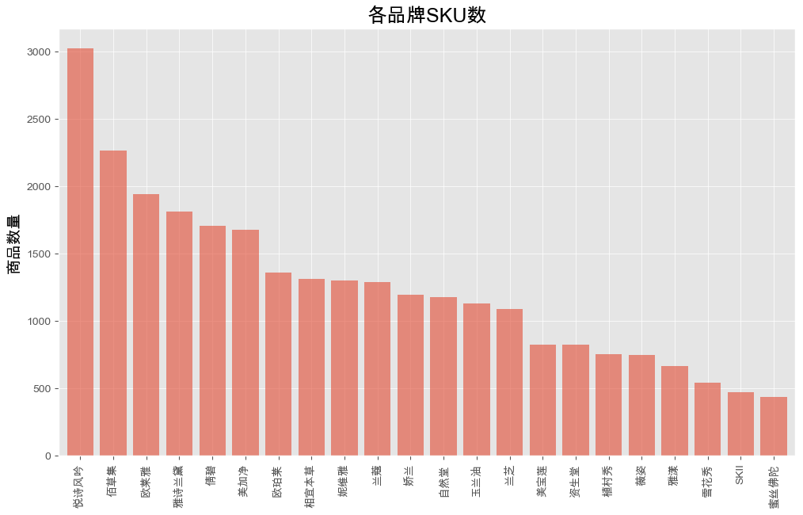

```python
plt.figure(figsize = (12, 7))
# 计算各店铺的商品数量
data['店名'].value_counts().sort_values(ascending=False).plot.bar(width=0.8, alpha=0.6)

plt.title('各品牌SKU数', fontsize=18)
plt.ylabel('商品数量', fontsize=14)
plt.show()
```

小结：由图可以大致将各品牌的SKU数量分为3个梯队。第一梯队：悦诗风吟（韩国）、佰草集（国产中高端）、欧莱雅（法国中档）、倩碧（美国雅诗兰黛）、美加净（国产）；第二梯队：欧珀莱（中日合资企业）、相宜本草（国产）、妮维雅（德国）、兰蔻（法国欧莱雅）、娇兰（法国）、自然堂（国产）、玉兰油（宝洁）、兰芝（韩国）；第三梯队：美宝莲（美国）、资生堂（日本独资）、植村秀（日本，2002年被欧莱雅收购）、薇姿（法国欧莱雅）、雅漾（法国）、雪花秀（韩国高端）、SKII（宝洁）、蜜丝佛陀（美国）。

### 4.2 各品牌总销售量和总销售额

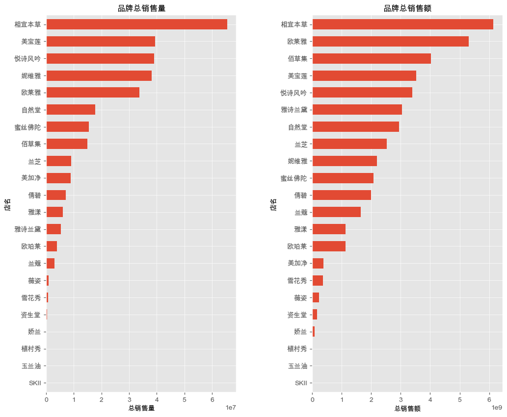

```python
fig, axes = plt.subplots(1, 2, figsize=(12, 10))

ax1 = data.groupby('店名').sale_count.sum().sort_values(ascending=True).plot(kind='barh',ax=axes[0],width=0.6)
ax1.set_title('品牌总销售量', fontsize=12)
ax1.set_xlabel('总销售量')

ax2 = data.groupby('店名').sale_amount.sum().sort_values(ascending=True).plot(kind='barh',ax=axes[1],width=0.6)
ax2.set_title('品牌总销售额', fontsize=12)
ax2.set_xlabel('总销售额')

plt.subplots_adjust(wspace=0.4)
plt.show()
```

小结：从销量和销售额前五来看，都在前五的有：相宜本草、美宝莲、悦诗风吟、欧莱雅。妮维雅销量第四，销售额第九。佰草集销售额第三，销量第八。

### 4.3 各品牌的价格

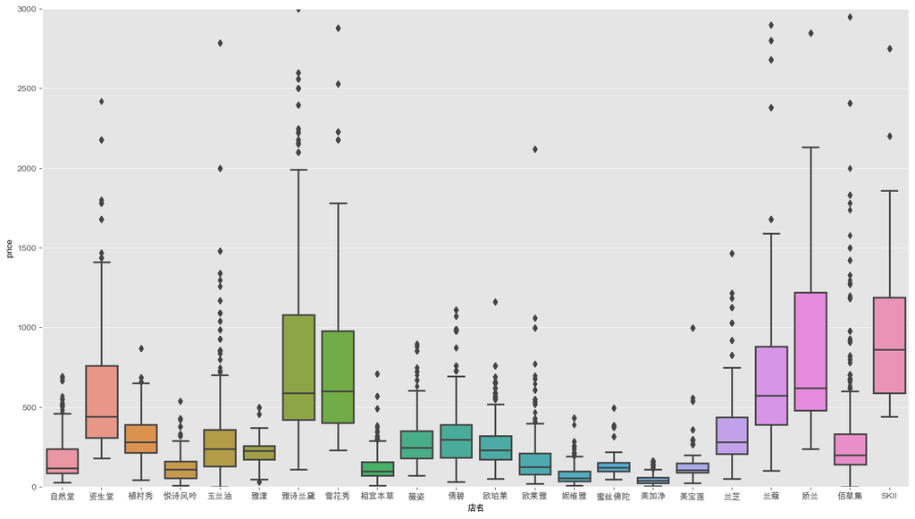

```python
# 查看各品牌价格的箱线图
plt.figure(figsize=(18,10))
sns.boxplot(x='店名', y='price', data=data)
plt.ylim(0, 3000) #如果不限制，就容易看不清箱型
plt.show()
```

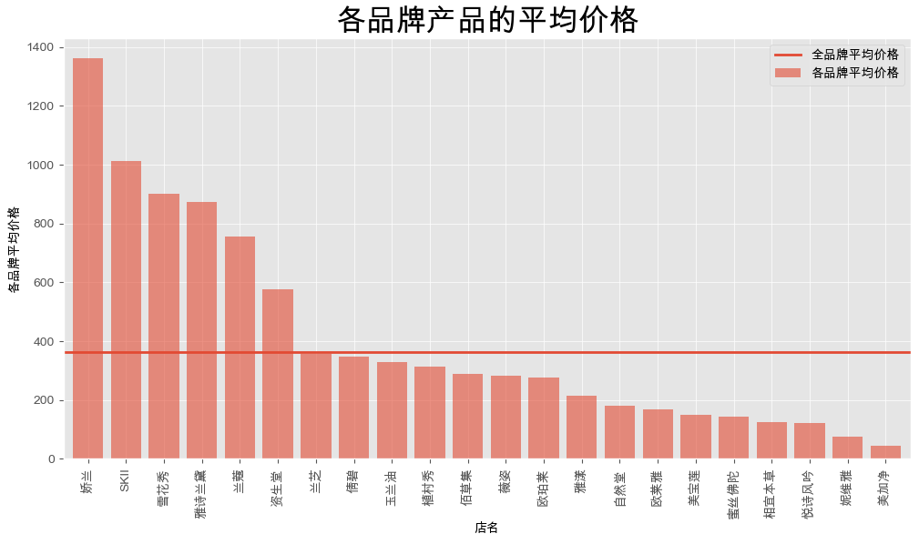

```python
# 各品牌平均价格
avg_price = data.groupby('店名').price.sum()/data.groupby('店名').price.count()

fig = plt.figure(figsize=(12,6))

avg_price.sort_values(ascending=False).plot.bar(width=0.8, alpha=0.6, label='各品牌平均价格')
plt.axhline(data['price'].mean(), 0, 5, label='全品牌平均价格')
plt.ylabel('各品牌平均价格')
plt.title('各品牌产品的平均价格', fontsize=24)
plt.legend(loc='best')
plt.show()
```

小结：娇兰、SKII、雪花秀、雅诗兰黛、兰蔻、资生堂这几个一线大牌的产品价格都很高，均价都在500以上；

兰芝、倩碧、玉兰油、植村秀、佰草集、薇姿、欧珀莱、雅漾的平均价格都在200到400元之间，其中佰草集是最贵的国货品牌；

美加净作为国货品牌，平均价格最低，性价比高；妮维雅平均价格第二低，所以前面能看出销量虽高，但销售额并不高；

全品牌的平均价格低于400元，除了前六个一线大牌，其余品牌的平均价格都低于全品牌平均价格。

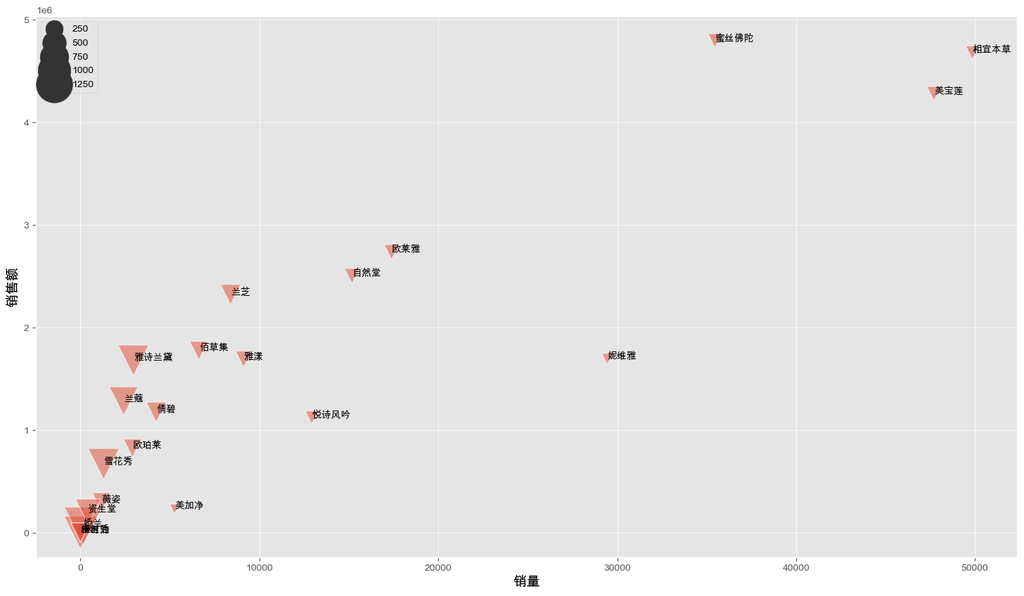

```python
plt.figure(figsize=(18,10))

x = data.groupby('店名')['sale_count'].mean()
y = data.groupby('店名')['sale_amount'].mean()
s = data.groupby('店名')['price'].mean()
txt = data.groupby('店名')['id'].count().index

sns.scatterplot(x=x, y=y, size=s, sizes=(100,1500),marker='v', alpha=0.5)

for i in range(len(txt)):
    plt.annotate(txt[i], xy=(x[i], y[i]), xytext=(x[i]+1.5, y[i]+1)) #在散点后面增加品牌信息的标签

plt.ylabel('销售额',fontsize=14)
plt.xlabel('销量', fontsize=14)
plt.legend(loc='upper left')
plt.show()
```

小结：该图表现了各品牌销量、销售额以及平均价格之间的关系。其中点越靠上，销售额越高，越考右，销量越高，点越大代表平均价格越高。

由图中点的走向，可以看出销量与销售额呈现正相关；

相宜本草、美宝莲、蜜丝佛陀销量较高，销售额也较高，价格相对较低； 雅诗兰黛、兰蔻、雪花秀这三个品牌销量和销售额都较低，但是价格较高； 说明销量、销售额与价格有着重要联系。

### 4.4 各品牌热度

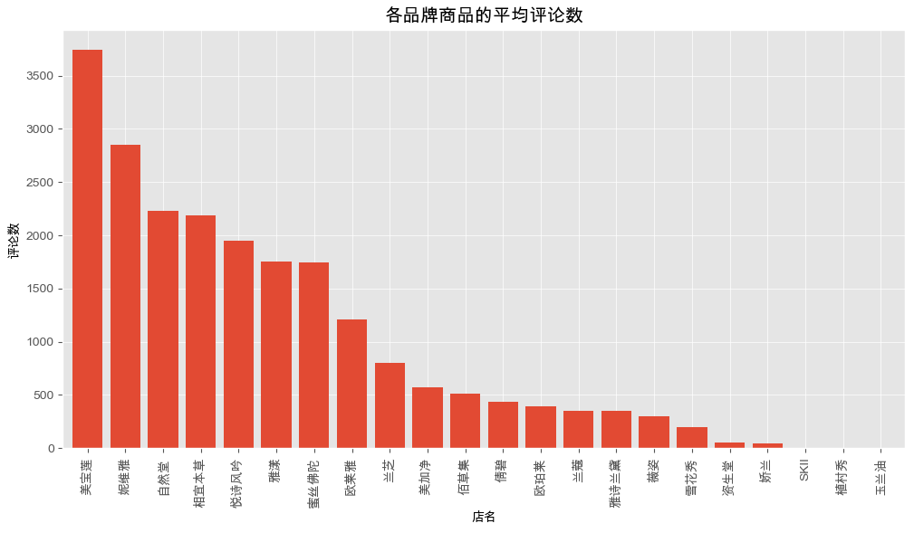

```python
plt.figure(figsize=(12,6))
data.groupby('店名').comment_count.mean().sort_values(ascending=False).plot.bar(width=0.8)
plt.title('各品牌商品的平均评论数')
plt.ylabel('评论数')
plt.show()
```

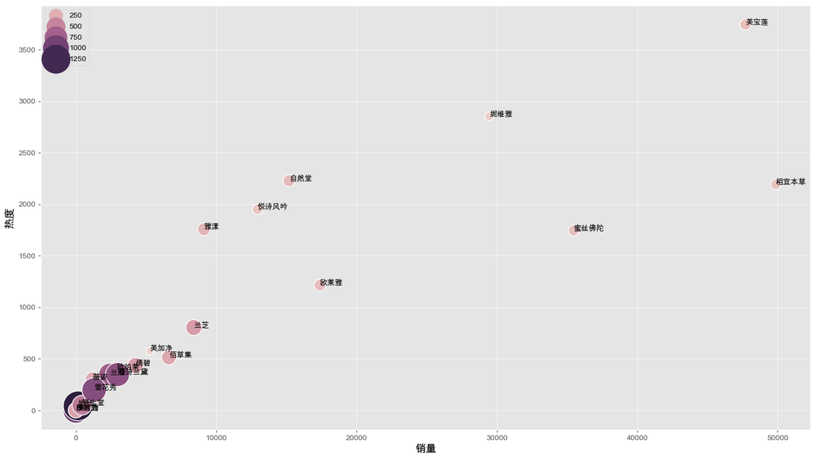

```python
plt.figure(figsize=(18,10))

x = data.groupby('店名')['sale_count'].mean()
y = data.groupby('店名')['comment_count'].mean()
s = data.groupby('店名')['price'].mean()
txt = data.groupby('店名')['id'].count().index

sns.scatterplot(x=x, y=y, size=s, hue=s, sizes=(100,1500))

for i in range(len(txt)):
    plt.annotate(txt[i], xy=(x[i], y[i])) #在散点后面增加品牌信息的标签

plt.ylabel('热度',fontsize=14)
plt.xlabel('销量',fontsize=14)
plt.legend(loc='upper left')
plt.show()
```

小结：图中横轴代表销量，纵轴代表热度，点的大小和颜色代表品牌平均价格。

可以看出销量与热度呈现正相关，销量越高，热度也越高。

雪花秀、雅诗兰黛、娇兰、兰蔻、资生堂等品牌销量低，价格高，热度也较小，符合市场规律；

欧莱雅、悦诗风吟、自然堂、雅漾等销量、热度和价格都比较适中；

美宝莲、妮维雅、相宜本草、蜜丝佛陀的销量较高，热度也较高，且这四个品牌的价格都相对较低，说明价格在热度和销量中有一定的影响。

### 4.5 各类别的销售量、销售额情况

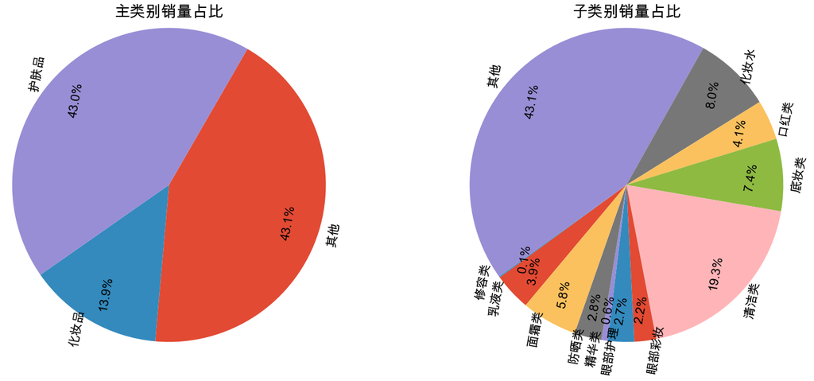

```python
fig, axes = plt.subplots(1, 2, figsize=(18,12))

data1 = data.groupby('main_type')['sale_count'].sum()
ax1 = data1.plot(kind='pie',ax=axes[0],
                 autopct='%.1f%%', #设置百分比的格式，这里保留一位小数
                 pctdistance=0.8, #设置百分比标签与圆心的距离
                 labels=data1.index,
                 labeldistance=1.05, #设置标签与圆心的距离
                 startangle=60, #设置饼图的初始角度
                 radius=1.2, #设置饼图半径
                 counterclock=False, #是否逆时针，这里设置为顺时针方向
                 wedgeprops={'linewidth':1.2}, #设置饼图内外边界的属性值
                 textprops={'fontsize':16, 'color':'k', 'rotation':80}, #设置文本标签的属性值
                 )
ax1.set_title('主类别销量占比',fontsize=20)

data2 = data.groupby('sub_type')['sale_count'].sum()
ax2 = data2.plot(kind='pie',ax=axes[1],
                 autopct='%.1f%%',
                 pctdistance=0.8,
                 labels=data2.index,
                 labeldistance=1.05,
                 startangle=230,
                 radius=1.2,
                 counterclock=False,
                 wedgeprops={'linewidth':1.2},
                 textprops={'fontsize':16, 'color':'k', 'rotation':80},
                 )
ax2.set_title('子类别销量占比', fontsize=20)

#设置坐标标签
ax1.set_xlabel('', fontsize=16, labelpad=38.5)
ax1.set_ylabel('', fontsize=16, labelpad=38.5)
ax2.set_xlabel('', fontsize=16, labelpad=38.5)
ax2.set_ylabel('', fontsize=16, labelpad=38.5)
plt.subplots_adjust(wspace=0.4)
plt.show()
```

小结：从主类别销量占比情况来看，护肤品类的销量远高于化妆品类；

从子类别销量占比情况来看，清洁类、面霜类和化妆水在护肤品中销量最多，底妆类、口红在化妆品中销量最多。

### 4.6 各品牌各总类别下的销量、销售额

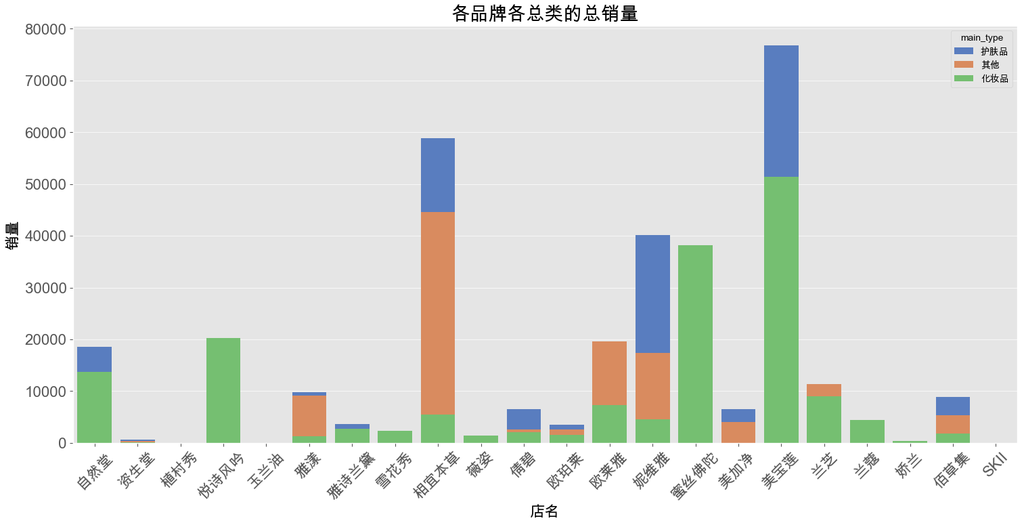

```python
plt.figure(figsize=(18,8))
sns.barplot(x='店名', y='sale_count', hue='main_type',data=data,palette='muted',dodge=False,saturation=0.75,errorbar=('ci',0))
plt.title('各品牌各总类的总销量', fontsize=20)
plt.ylabel('销量', fontsize=16)
plt.xlabel('店名',fontsize=16)
plt.xticks(fontsize=16,rotation=45)
plt.yticks(fontsize=16)
plt.show()
```

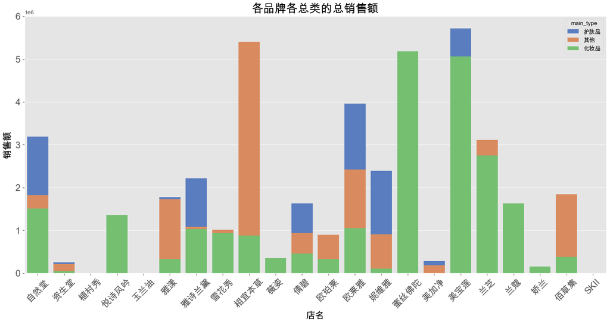

```python
plt.figure(figsize=(18,8))
sns.barplot(x='店名', y='sale_amount', hue='main_type',data=data,palette='muted',dodge=False,saturation=0.75,errorbar=('ci',0))
plt.title('各品牌各总类的总销售额', fontsize=20)
plt.ylabel('销售额', fontsize=16)
plt.xlabel('店名',fontsize=16)
plt.xticks(fontsize=16,rotation=45)
plt.yticks(fontsize=16)
plt.show()
```

小结：各品牌化妆品、护肤品的销量和销售额情况都不一样，这与品牌的定位有关，有的品牌主导化妆品，有的品牌主打护肤品。

根据销量情况来看，护肤品销量较高的有：美宝莲、妮维雅、相宜本草、自然堂；化妆品销量较高的有：美宝莲、蜜丝佛陀、悦诗风吟、自然堂。

根据销售额情况来看，护肤品销售额排名前列的有：欧莱雅、妮维雅、雅诗兰黛、自然堂；化妆品销售额较高的有：蜜丝佛陀、美宝莲、兰芝、自然堂。

其中，自然堂是属于护肤品、化妆品的销量和销售额都还不错。妮维雅的护肤品销量和销售额都表现不错，说明其主打的是护肤品；美宝莲和蜜丝佛陀都主打的是化妆品。

### 4.7 各品牌各子类别下的销量、销售额

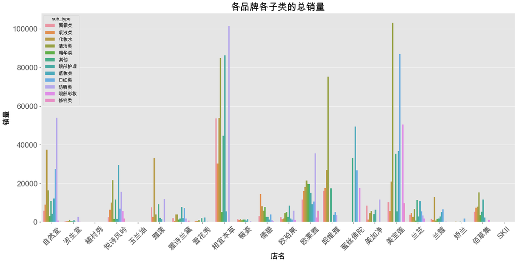

```python
plt.figure(figsize=(18,8))
sns.barplot(x='店名', y='sale_count', hue='sub_type',data=data,saturation=0.75,errorbar=('ci',0))
plt.title('各品牌各子类的总销量', fontsize=20)
plt.ylabel('销量', fontsize=16)
plt.xlabel('店名',fontsize=16)
plt.xticks(fontsize=16,rotation=45)
plt.yticks(fontsize=16)
plt.show()
```

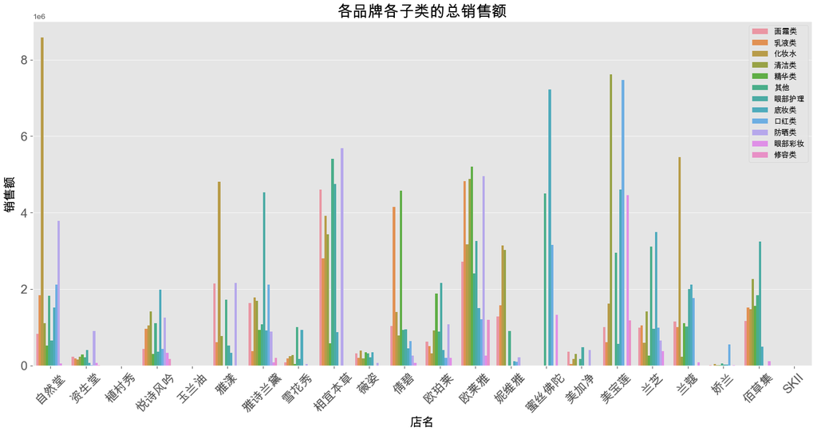

```python
plt.figure(figsize=(18,8))
sns.barplot(x='店名', y='sale_amount', hue='sub_type',data=data,saturation=0.75,errorbar=('ci',0))
plt.title('各品牌各子类的总销售额', fontsize=20)
plt.ylabel('销售额', fontsize=16)
plt.xlabel('店名',fontsize=16)
plt.xticks(fontsize=16,rotation=45)
plt.yticks(fontsize=16)
plt.legend(loc=1)
plt.show()
```

小结：护肤品中，清洁类表现最好的有美宝莲、妮维雅、相宜本草；面霜类表现最好的有相宜本草、欧莱雅、雅漾、雅诗兰黛；化妆水表现最好的品牌有相宜本草、雅漾、自然堂。

化妆品中，底妆卖的最好的有蜜丝佛陀、美宝莲、兰芝；口红卖得最好的有蜜丝佛陀、美宝莲、自然堂、雅诗兰黛。

### 4.8 男性美妆用品销量情况

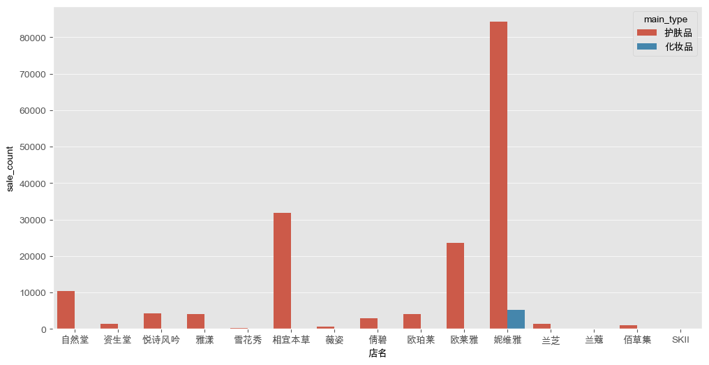

```python
gender_data = data[data['是否男士专用']=='是']
gender_data1 = gender_data[(gender_data.main_type=='护肤品')|(gender_data.main_type=='化妆品')]
plt.figure(figsize=(12,6))
sns.barplot(x='店名',y='sale_count',hue='main_type',data=gender_data1,saturation=0.75,errorbar=('ci',0))
plt.show()
```

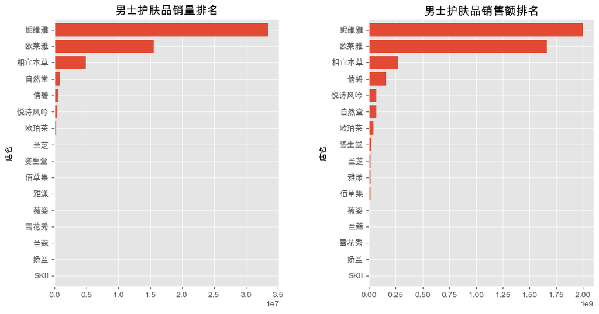

```python
f, [ax1, ax2]=plt.subplots(1, 2, figsize=(12,6))
gender_data.groupby('店名').sale_count.sum().sort_values(ascending=True).plot(kind='barh',width=0.8,ax=ax1)
ax1.set_title('男士护肤品销量排名')

gender_data.groupby('店名').sale_amount.sum().sort_values(ascending=True).plot(kind='barh',width=0.8,ax=ax2)
ax2.set_title('男士护肤品销售额排名')

plt.subplots_adjust(wspace=0.4)
plt.show()
```

小结：男士购买的大多是护肤品，化妆品很少。

妮维雅在男士护肤品中销量和销售额都很高，说明男士对妮维雅品牌的认可度很高。第二、第三分别为欧莱雅和相宜本草。

### 4.9 时间与销量的关系

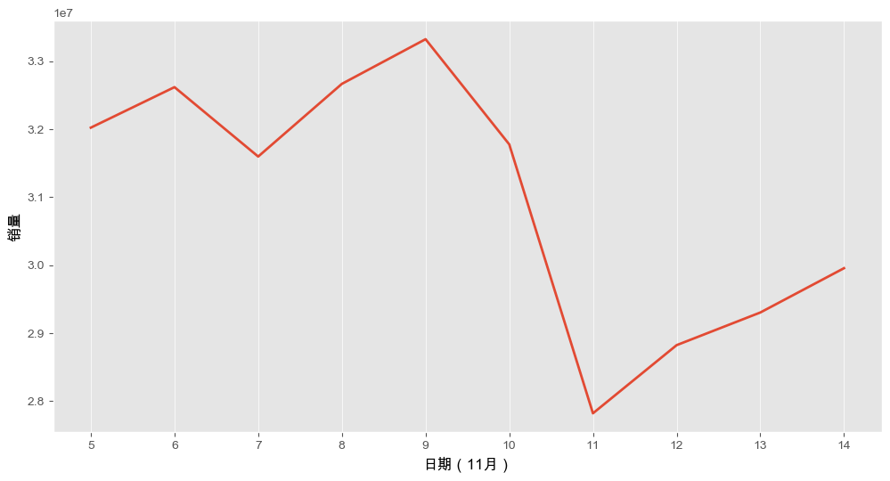

```python
plt.figure(figsize=(12,6))
day_sale = data.groupby('day')['sale_count'].sum()
day_sale.plot()
plt.grid(axis="y") #只保留纵轴网格线
plt.xticks(np.arange(5, 15, 1)) #将刻度调整为1
plt.xlabel('日期（11月）', fontsize=12)
plt.ylabel('销量',fontsize=12)
plt.show()
```

## 五、总结

从商品销售主类别来看，护肤品的销量远远大于化妆品。从销售子类别来看，护肤品中清洁类、化妆水和面霜类的销量占比较高；化妆品中底妆类、口红类的销量占比较高。

男士购买美妆主要集中在护肤品中，且妮维雅品牌是最受男士喜爱的品牌。

由于商家在双十一提前预热，巨大的优惠力度和为了避免网络高峰，不少消费者选择提前消费，销量高峰出现在双十一前几天；双十一后3天商家持续打折优惠，消费者仍有购物余热，但远不如双十一以前。

## 六、建议

消费者对于产品评价和价格关注度较高，品牌可以适当调整产品价格并通过诸如网络社交平台的方式提高品牌热度。

对于男性消费者，品牌可以定向推荐评价基础护肤品，在销量中可以看到也有一部分男性购买化妆品，品牌可以在护肤品中适当捆绑化妆品，带动化妆品类消费。

消费者购买欲望并不集中在双十一当天，商家可以提前预热加大优惠力度刺激消费者提前消费，避免网络高峰。消量高峰出现在双十一前几天，说明消费者很可能是在观望优惠力度，可以推出“买贵必赔”，这样消费高峰期也不会拥堵。